# RPlot

Group 4

11/16/2021

# Contributor Statement

Chad, Sai and Rhonda each contributed to the project plan. Sai worked on Research Question 1 Chad worked on Research Question 2 Rhonda worked on Research Question 3 Rhonda proofread

Each person went ahead and readdressed their research question from the initial “Research Questions” assignment. Secondly, each person chose a particularly informative plot that best-fit or best-explained the exploration and analysis of their research question. Thirdly, each person provided their own explanation of their plot in one or two paragraphs. Chad combined the work of all three team persons and Rhonda performed the proofreading.

# Research Question 2

HFS facility locations have a significant effect on the number of missed appointments.

The research question builds on existing knowledge that Omaha and Iowa contain pockets of segregated populations, both in terms of ethnicity, finances, and priviledge. The research question poses that location might have a significant effect on missed appointments. If a particular location has a population with financial access to vehicles, or even multiple vehicles, they might be more able to make their appointments. Initially, we hope to identify that facility location affects missed appointments. If we can show this is true, we can further explore what about the facility location negatively affects client’s ability to make their appointments. This research data specifically looks at the mental health program, the largest for HFS. This research also breaks down no shows by the type of therapist, knowing that different types of therapists might handle different appointments, each of which might be related to the likelihood of missing appointments. This research quesiton does not break down the data by ethnicity, only because the ethnicity counts were not large enough to be meaningful for each facility and job title.

```r
library('tidyverse')
```

```r
library('ggplot2') # for sample plot if required
library('dplyr') # to use pipelines '%>%' for data set
```

```r
HFS_data<-read.csv("HFS Service Data.csv") # read data set
```

```r
data <- HFS_data
therapists = data %>% filter(data$job_title == "THERAPIST I" | data$job_title == "THERAPIST II" | data$job_title == "THERAPIST III" | data$job_title == "LEAD THERAPIST" | data$job_title == "Therapist")
```

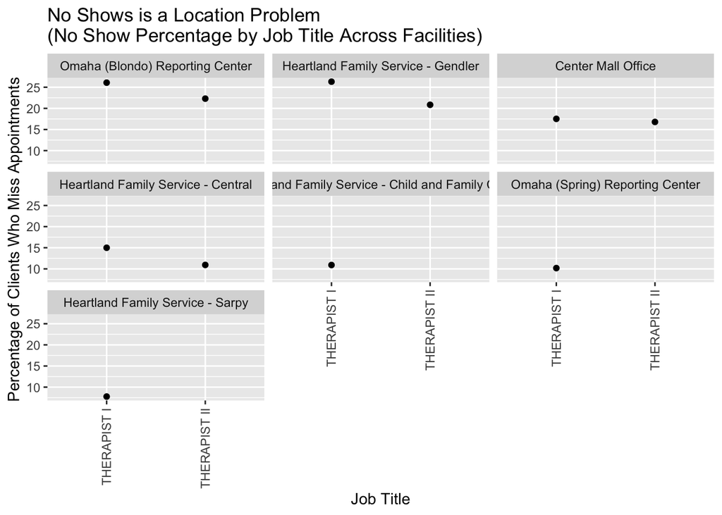

```r
# possibly look at no show rate by facility
mental_health <- therapists %>% filter(program_name == "Mental Health")
noshow_stats <- mental_health %>% group_by(facility, job_title) %>% count(is_noshow) %>% filter(n > 20)
noshows <- noshow_stats %>% filter(is_noshow == "FALSE")
shows <- noshow_stats %>% filter(is_noshow == "TRUE")
noshow_stats_consolidated <- inner_join(shows,noshows,by=c("facility","job_title"), suffix = c("no", "yes"))
#noshow_stats_consolidated <- select(noshow_stats_consolidated, -c(is_noshowno, is_noshowyes))
noshow_percent <- noshow_stats_consolidated %>% add_column(noshow_percent = .$nno / (.$nyes + .$nno) * 100)
df <- noshow_percent

ggplot(data = df) + geom_point(mapping = aes(x = reorder(job_title,noshow_percent), y = noshow_percent))  + facet_wrap(~ reorder(facility, -noshow_percent)) +
ggtitle("No Shows is a Location Problem\n(No Show Percentage by Job Title Across Facilities)") +
xlab("Job Title") +
ylab("Percentage of Clients Who Miss Appointments") +
 theme(axis.text.x = element_text(angle = 90, vjust = 0.5, hjust=1), legend.position = "none")
```

The takeaway is that no show percentage is tightly related to the facility. This means that the rate at which clients skip or miss appointments is tightly coupled with the specific facility. This means that some facilities show much higher rates of appointment misses than others. For example, the Gendler HFS location should expect very high appointment no shows, up to 25% contrasted with the Sarpy location that averages fewer than 10% no shows.

HFS should seek to understand why location is closely coupled to missing appointments. This might be related to particular locations being more difficult to access, such as difficult traffic or limited parking. On the other hand, each location might have very different populations, whether via ethnicity or financial differences that provide different levels of priviledge, which in turn affect client’s ability to allocate time for appointments. Further research should seek to understand what about location or the clients that visit these locations affect missed appointments.